# GEN Z, sin miedo a invertir

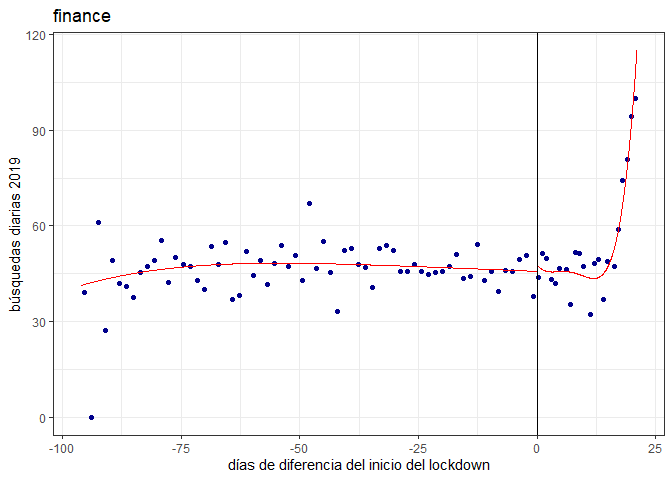

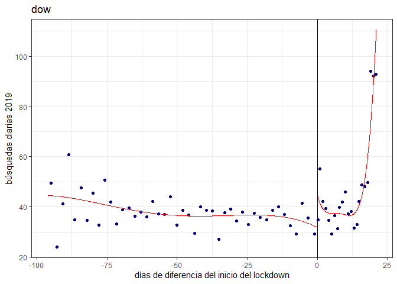

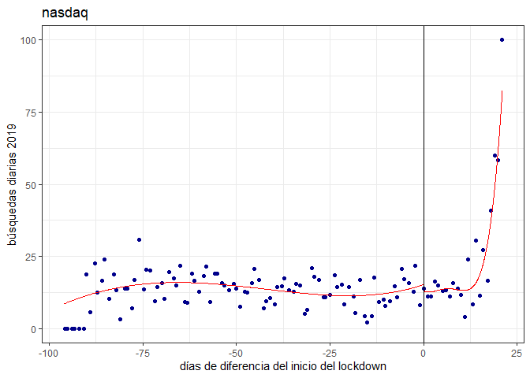

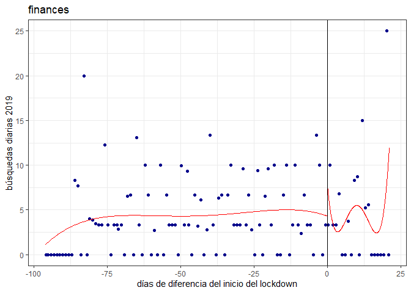

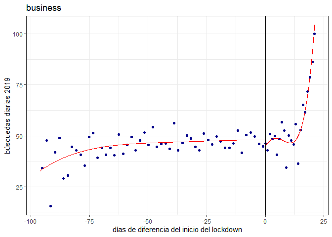

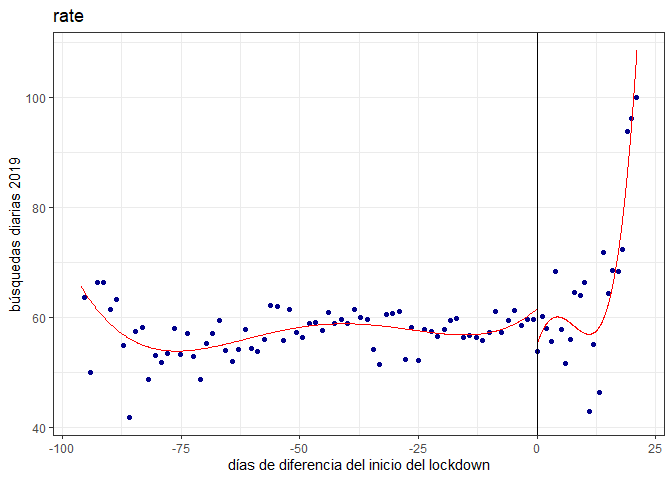

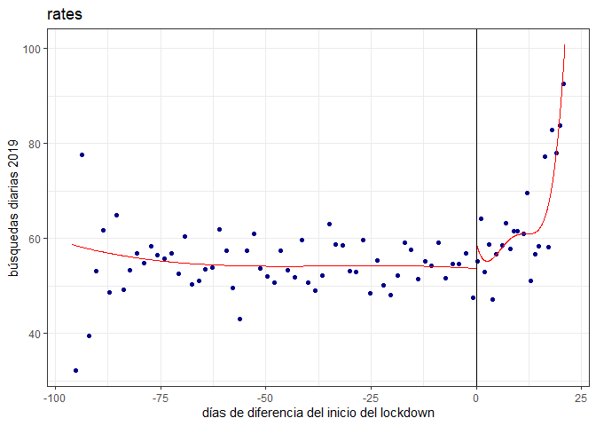

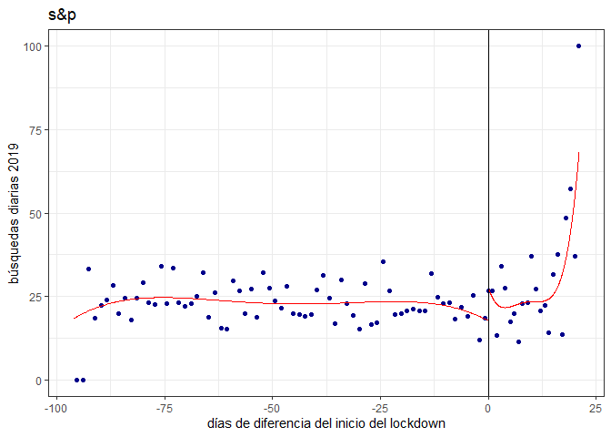

## Conclusiones

A partir de ambos métodos utilizados para estimar si hubo un efecto causal que aumentara el número de búsquedas relacionadas a finanzas se puede concluir lo siguiente. Con el método DiD que compara el promedio de búsquedas en el periodo del 1 de enero al 4 de abril de 2019 y luego para el 2020 se puede concluir que el efecto del lockdown aumentó el número de búsquedas de términos relacionados a finanzas teniendo un importante impacto en palabras como S&P, Stocks y Dow Jones esto no es nada sorpresivo, ya que se esperaba que sí hubiera un aumento, dado que como se mencionó al principio la Gen Z ha decidido que la pandemia no iba a impedirles aprovechar para invertir.

Por otro lado, el método RD que se refiere a la regresión discontinua para medir el impacto inmediato del lockdown nos indicó que no fue significativo el aumento en búsquedas al día siguiente del anuncio del lockdown, sin embargo, este resultado era de esperarse puesto que se piensa que a partir de las dos semanas o un poco más de tiempo de lockdown empezó a surgir el interés por parte de la población en inversiones y otros temas de este índole. Y se confirma esta teoría al revisar las gráficas y observar que hubo un aumento significativo en las búsqueda a partir de la segunda semana del lockdown para la mayoría de los términos.

Por lo tanto, concluimos que quizá en los resultados no se aprecia en todas las palabras que el confinamiento animó a muchas personas a considerar la bolsa como un a fuente extra de ingresos. Este hecho puede deberse a que al mismo tiempo de que muchas personas voltearon a ver esta alternativa, muchas otras vieron en los mercados financieros mucha incertudumbre. Por lo que el efecto se pudo haber neteado por ambos casos de personas. Esta suposición la puede respaldar el hecho de que, aunque en promedio el nivel de búsquedas no fue muy significativo, la varianza del nivel de búsquedas si aumentó. Por lo tanto, aumentó la volatilidad en las búsquedas. Que haya habido más volatilidad en las búsquedas defiende también nuestra hipótesis de que más gente se interesó en la bolsa en especial los más jóvenes pertenecientes a la Gen Z. Así que la próxima vez que veas a un Gen Z pregúntale si en este útlimo año se ha interesado por sus finanzas personales y que si invierte en la bolsa, y lo más probable es que recibas un sí, confirmando nuestra hipótesis de que a aprtir de la pandemia y el lockdwon causados por el COVID19 más gente empezó a buscar temas relacionados con finanzas.

## Apéndeice estadístico

### Procedimiento de escala:

Denotemos con $D_{i,c,2019}$ el número de búsquedas diarias en Google de un tema el día $i$ en el estado $c$, durante el período del 1 de enero de 2019 al 10 de abril de 2019, con un número análogo $D_{i,c,2020}$ para el período del 1 de enero de 2020 al 10 de abril de 2020. Estos datos se obtienen para cada día individual $i$ y toman valores entre 0 y 100 para cada día durante el período considerado. Sin embargo, no se puede comparar directamente los números de 2019 y 2020 ya que su denominador (el número máximo de búsquedas durante un día en el período) no es el mismo. Para poder comparar estas cifras, cambiamos la escala de los datos diarios para cada período por las respectivas ponderaciones de interés de búsqueda de la semana que calculamos utilizando datos semanales que están disponibles continuamente durante todo el periodo entre el 1 de enero de 2019 y el 10 de abril de 2020.

Denotemos por $D_{i,c,2019-2020}$ el número reescalado de búsquedas diarias en Google para este tema el día $i$ en el estado $c$ durante el período del 1 de enero de 2019 al 10 de abril de 2020. Este factor lo calculamos de la siguiente manera:

Primero calculamos los respectivos niveles de busqueda semanal de los temas de nuestro interés para todas las semanas entre el 1 de enero de 2019 y el 10 de abril de 2020. Tomamos los datos diarios desde el 1 de enero de 2019 hasta el 10 de abril de 2019 y calculamos el promedio de búsquedas semanales para cada tema en el país $c$ sobre este periodo y lo denotamos $D_{i,c,2019}$. Luego realizamos el mismo ejercicio para el periodo del 1 de enero de 2020 al 10 de abril de 2020 y lo denotamos: $D_{i,c,2020}$. De igual manera sacamos el promedio del nivel de busqueda de cada tema para todo el periodo (es decir, desde el 1 de enero de 2019 hasta el 10 de abril de 2020), también lo denotamos: $D_{i,c,2019-2020}$

De lo anterior ponderamos el nivel de las búsquedas semanales, $w_{c,2019}$ y $w_{c,2020}$: $w_{c,2019}= \frac{\overline{D_{i,c,2019-2020}}}{D_{i,c,2019}}$ y $w_{c,2020}= \frac{\overline{D_{i,c,2019-2020}}}{D_{i,c,2020}}$

Con estas ponderaciones ahora podemos cambiar la escala de los datos diarios para cada período multiplicando $D_{i,c,2019}$ por $w_{c,2019}$ en 2019 y $D_{i,c,2020}$ por $w_{c,2020}$ en 2020. Obtenemos:
$$D_{i,c,2019-2020}=D_{i,c,2019}*\frac{\overline{D_{i,c,2019-2020}}}{D_{i,c,2019}}$$
para 2019
$$D_{i,c,2019-2020}=D_{i,c,2020}*\frac{\overline{D_{i,c,2019-2020}}}{D_{i,c,2020}}$$
para 2020

Por último, normalizamos estas cifras para obtener cifras entre 0 y 100 remplazando $D_{i,c,2019-2020}$ por:
$$D_{i,c,2019-2020}=\frac{D_{i,c,2019-2020}}{max(D_{i,c,2019-2020})}*100$$

### Selección de la muestra:

Utilizamos la informsción que Google Trends nos proporciona sobre el historial de busqueda de las personas en Estados Unidos, no solo porque fue uno de los paises que con mayor rapidez impusieron restricciones de confinamiento, sino también porque la cultura de la inversión digital en la bolsa de valores es mucho más común, porque una mayor cantidad de personas tienen acceso a internet. De esta manera suavizamos un poco el sesgo que podría existir en nuestra muestra por la exclusión de personas que no tienen acceso a internet para nuestro ejercicio. Este sesgo es una de las desventajas que tiene utilizar Google Trends como fuente de datos, así como el sesgo por edades, porque es mucho más común que la gente joven utilice internet para buscar maneras de invertir en la bolsa, mientras la gente de edad lo puede hacer por otro medio. Esto podría excluir de nuestro ejercicio a muchas personas mayores.

Sin embargo, utilizar Google Trends en nuestro trabajo tiene también ventajas; primero, las muestras que obtenemos son grandes, por lo que se elimina el sesgo por muestras pequeñas. Segundo, no adolece de sesgos como el efecto expectativa del observador o el sesgo del entrevistador, porque los usuarios no tienen incentivos a mentir en sus búsquedas privadas. Y tercero, no hay una submuestra de entrevistados, por lo que no participa en nuestro ejercicio gente auto informada.

### Método:

Para estimar los efectos del confinamiento en las búsquedas relacionadas con el sector financiero, nos basamos en una estimación de Diferencia en Diferencia (DiD) que compara las búsquedas antes y después de la cuarentena en 2020 con las búsquedas anteriores y posteriores a la misma fecha en 2019, esto garantiza que los cambios estacionales no afectan nuestro ejercicio porque comparamos las mismas fechas, en diferentes años.

Escribimos el modelo de regresión de diferencias en diferencias para un término $W$ como:
$$W_{i,c}=\alpha T_{i,c}*Year_{i}+\beta T_{i,c}+\mu_{i}+\rho_{c}+\epsilon_{i,c}$$

Los errores estándar son robustos y están agrupados a nivel de día. La suposición clave en nuestro ejercicio es que, en ausencia del confinamiento, el comportamiento de los usuarios de Google habría evolucionado de la misma manera que en el año anterior al *lockdown*, es decir, una suposición de tendencia común.

### Estimadores RDD (Regresión discontinua)

Para investigar si hay una ruptura estructural inmediata causada por el confinamiento en las tendencias de búsqueda de inversiones, también utilizaremos el método de regresión discontinua (RDD), que identifica rupturas en dos series paramétricas estimadas antes y después del confinamiento. Al igual que con las estimaciones de DiD, comparamos estas rupturas con las estimadas durante el mismo período en 2019.

Sea $D$ la variable de ejecución, que se define como la distancia absoluta en días desde el anuncio de la orden de confinamienro; es negativo para los días anteriores y positivo para los días posteriores, mientras que la fecha del anuncio real o contrafactual se establece como día cero. El anuncio de bloqueo $T_{i,c}$ se define como ya lo habíamos definido anteriormente. Por lo tanto, el modelo RDD-DiD se puede escribir de la siguiente manera:
$$\small W_{i,c}=\alpha\prime T_{i,c}*Year_{i}+ \psi f(D_{i,c})*Year_{i}+\theta f(D_{i,c})(1-T_{i,c})*Year_{i}+\phi f(D_{i,c})*(1-T_{i,c})$$

$$+\beta\prime T_{i,c} + \gamma X_{i-1,c} + \mu\prime_{i}+ \rho\prime_{c}+ \epsilon\prime_{i,c}$$

Donde $\alpha\prime$ refleja el efecto que causó el confinamiento en las búsquedas de Google del término $W_i$, $c$ en el día $i$ en el estado $c$. $f(D_{i,c})$ es una función polinomial de la distancia en días desde el anuncio del confinamiento que interactuó con la variable dummy de *lockdown* $T_{i,c}$, para permitir diferentes efectos en ambos lados de las regresiones (antes y después). Además, se incluyeron los mismos controles que en los modelos DID.

#### Resultados del *DiD*

Esta tabla muestra la estimación de diferencias en diferencias. En este modelo la variable dependiente es hits_corrected, que se refiere al nivel de búsqueda que hay de cierta palabra, en este caso las selecionadas, en un día. La escala de estos niveles está en un rango de 0 a 100. El modelo incluye como controles una variable dummy que toma el valor 1 en los días posteriores al anuncio del confinamiento y 0 en los días anteriores, así como los efectos fijos de los estados, año, semana, día y el número de nuevas muertes con retraso de un día. Los errores estándar están entre paréntesis. Los errores estándar se agrupan a nivel de día.

##### Efectos del lockdown estimado por *DiD* para los términos_Stock_, *Stocks*, *Market*, *NYSE*, *Finance* y *Dow Jones*

Efecto del lockdown en las búsquedas

|  | stock | stocks | market | nyse | finance | dow |
| --- | --- | --- | --- | --- | --- | --- |
| efecto x lockdown = 2020 | 0.92 (1.9) | 5.8** (2.1) | -0.61 (2.4) | 4.9 (3.0) | -0.06 (1.6) | 5.8* (2.7) |
| Fixed-Effects: | ———- | ———– | ———– | ——— | ———– | ———- |
| weekday | Yes | Yes | Yes | Yes | Yes | Yes |
| geo | Yes | Yes | Yes | Yes | Yes | Yes |
| week | Yes | Yes | Yes | Yes | Yes | Yes |
| lockdown | Yes | Yes | Yes | Yes | Yes | Yes |
| ________________________ | __________ | ___________ | ___________ | _________ | ___________ | __________ |
| S.E.: Clustered | by: date | by: date | by: date | by: date | by: date | by: date |
| Observations | 10,251 | 10,251 | 10,251 | 9,849 | 10,251 | 10,251 |
| R2 | 0.69300 | 0.27175 | 0.43492 | 0.16845 | 0.42001 | 0.42174 |
| Within R2 | 0.00057 | 0.00192 | 4.39e-5 | 0.00132 | 0.00032 | 0.00176 |
| Weights by State | Yes | Yes | Yes | Yes | Yes | Yes |
| FE by COVID Deaths | Yes | Yes | Yes | Yes | Yes | Yes |

### Efectos del lockdown estimado por *DiD* para los términos *Nasdaq*, *Finances*, *Business*, *Rate*, *Rates* y *S&P*

|  | nasdaq | finances | business | rate | rates | s&p |
| --- | --- | --- | --- | --- | --- | --- |
| efecto x lockdown = 2020 | 1.3 (2.8) | 0.76 (2.3) | -0.55 (2.0) | -0.75 (1.6) | 1.1 (1.9) | 7.4** (2.6) |
| Fixed-Effects: | ——— | ———- | ———– | ———– | ——— | ———– |
| weekday | Yes | Yes | Yes | Yes | Yes | Yes |
| geo | Yes | Yes | Yes | Yes | Yes | Yes |
| week | Yes | Yes | Yes | Yes | Yes | Yes |
| lockdown | Yes | Yes | Yes | Yes | Yes | Yes |
| ________________________ | _________ | __________ | ___________ | ___________ | _________ | ___________ |
| S.E.: Clustered | by: date | by: date | by: date | by: date | by: date | by: date |
| Observations | 10,150 | 7,442 | 10,251 | 10,251 | 10,251 | 10,151 |
| R2 | 0.19013 | 0.03872 | 0.21356 | 0.27120 | 0.21596 | 0.23124 |
| Within R2 | 0.00061 | 0.00110 | 2.05e-5 | 4.29e-5 | 8.5e-5 | 0.00179 |
| Weights by State | Yes | Yes | Yes | Yes | Yes | Yes |
| FE by COVID Deaths | Yes | Yes | Yes | Yes | Yes | Yes |

Note: Signif. codes: *** p<0.001 ** p<0.01 * p<0.05

Estas dos tablas son los resultados del modelo de *Diferencias en Diferencias* que se realizó para cada una de las palabras que consideramos relevantes. Cada columna describe un modelo para cada término. Los modelos incluyen controles para una variable dummy que toma el valor 1 en los días posteriores al confinamiento y 0 en los días anteriores, así como efectos fijos de estado, semana y día. Los errores estándar están entre paréntesis. Los errores estándar se agrupan a nivel de día. Recordemos que la forma en la que se midieron las busquedas realizadas para cada palabra fue en una escala de niveles que van del 0 al 100 para hacer comparables los años 2019 y 2020.

##### Efectos del lockdown estimado por *RDD* para los términos_Stock_, *Stocks*, *Market*, *NYSE*, *Finance* y *Dow Jones*

Efecto del lockdown en las búsquedas

|  | stock | stocks | market | nyse | finance | dow |
| --- | --- | --- | --- | --- | --- | --- |
| death | -0.002. (0.0009) | -0.0002 (0.0008) | 0.0008 (0.0006) | 0.002 (0.003) | -0.002* (0.0008) | -0.0004 (0.0007) |
| efecto x lockdown = 2020 | 2.0 (2.7) | 5.7. (3.0) | 1.2 (3.5) | -6.3 (4.5) | -1.3 (2.5) | 1.5 (3.3) |
| Fixed-Effects: | —————- | —————- | ————— | ————- | —————- | —————- |
| weekday | Yes | Yes | Yes | Yes | Yes | Yes |
| geo | Yes | Yes | Yes | Yes | Yes | Yes |
| week | Yes | Yes | Yes | Yes | Yes | Yes |
| lockdown | Yes | Yes | Yes | Yes | Yes | Yes |
| ________________________ | ________________ | ________________ | _______________ | _____________ | ________________ | ________________ |
| S.E.: Clustered | by: date | by: date | by: date | by: date | by: date | by: date |
| Observations | 8,557 | 8,557 | 8,557 | 8,358 | 8,557 | 8,557 |
| R2 | 0.71149 | 0.27633 | 0.44541 | 0.16823 | 0.43235 | 0.44074 |
| Within R2 | 0.00103 | 0.00518 | 9.11e-5 | 0.00908 | 0.00125 | 0.01520 |
| Weights by State | Yes | Yes | Yes | Yes | Yes | Yes |
| FE by COVID Deaths | Yes | Yes | Yes | Yes | Yes | Yes |

### Efectos del lockdown estimado por *RDD* para los términos *Nasdaq*, *Finances*, *Business*, *Rate*, *Rates* y *S&P*

[output not shown]

Note: Signif. codes: *** p<0.001 ** p<0.01 * p<0.05

## Apéndice de contribuciones

Miguel y Anahí investigaron los términos de búsqueda que se utilizaron para construir la base de datos. Miguel hizo todo el código para bajar la base de datos de Google Trends y plantear el DiD y la regresión discontinúa. Anahí se encargó de crear el blog y darle todo el diseño y estructura y juntar toda la información para que hubiera coherencia. Alejandro Gómez se encargo de describir la metodología utilizada y dar interpretación junto con Anahí a los resultados. Miguel realizó las gráficas y tablas para los resultados y todos ayudaron a las conclusiones. Alejandro Ortiz no participó en el trabajo de manera activa

## Referencias

Brodeur A. et al (2020). COVID-19, Lockdowns and Well-Being: Evidence from Google Trends. Bonn, Alemania: IZA- Institute of Labor Economics. . Recuperado de http://ftp.iza.org/dp13204.pdf